# BigDAD

Sessie 1 - Kennismaken met tools en materiaal

## Laad de benodigde libraries

Om de data te analyseren zijn een aantal functies nodig. Sommige generieke functies worden direct bij de installatie van R meegeleverd. Andere functies zijn alleen in bepaalde situaties nodig en kunnen geladen worden op het moment dat ze een toepassing hebben. Dit voorkomt dat het geheugen van de computer onnodig wordt geblokkeerd.

Functies zijn vaak samengevoegd in packages. Zo zijn er een packages voor inlezen van [Google Spreadsheets](https://github.com/maxconway/gsheet), voor [tekstanalyse](https://www.tidytextmining.com/tidytext.html) of voor het analyseren van [netwerken](http://igraph.org/r/). Zie hier voor een overzicht van nuttige packages binnen het data-analyse proces.

```r
library(tidyverse)  # Functies voor het bewerken van datasets (filteren, transformeren ...)
library(readxl)     # Functies voor werken met Excel-bestanden
```

## Lees data in

De dataset is door wetenschappers van IBM gecreëerd om een use case van hun Watson Analytics systeem te illustreren. Een Excelversie kan [hier](https://www.ibm.com/communities/analytics/watson-analytics-blog/hr-employee-attrition/) worden opgehaald.

Met de functie `read_xlsx()` kan de data uit het Excel-bestand worden ingelezen. Het is een goede gewoonte om parameters eerst in variabelen op te slaan en pas daarna in een functie te gebruiken. Dit bevordert de leesbaarheid van de code.

De ingelezen data wordt opgeslagen in een variabele (`rawDF`). We kunnen de eerste zes regels van de dataset bekijken met de functie `head()`. De dataset is geïndexeerd (rij/kolom) en hiermee kunnen specifieke regels worden opgevraagd.

```r
url <- "datasets/hr/hr.xlsx"
rawDF <- read_xlsx(url)
head(rawDF)
```

| Age | Attrition | BusinessTravel | DailyRate | Department | DistanceFromHome | Education | EducationField | EmployeeCount | EmployeeNumber | EnvironmentSatisfaction | Gender | HourlyRate | JobInvolvement | JobLevel | JobRole | JobSatisfaction | MaritalStatus | MonthlyIncome | MonthlyRate | NumCompaniesWorked | Over18 | OverTime | PercentSalaryHike | PerformanceRating | RelationshipSatisfaction | StandardHours | StockOptionLevel | TotalWorkingYears | TrainingTimesLastYear | … |
| --- | --- | --- | --- | --- | --- | --- | --- | --- | --- | --- | --- | --- | --- | --- | --- | --- | --- | --- | --- | --- | --- | --- | --- | --- | --- | --- | --- | --- | --- | --- |
| 41 | Yes | Travel_Rarely | 1102 | Sales | 1 | 2 | Life Sciences | 1 | 1 | 2 | Female | 94 | 3 | 2 | Sales Executive | 4 | Single | 5993 | 19479 | 8 | Y | Yes | 11 | 3 | 1 | 80 | 0 | 8 | 0 | … |
| 49 | No | Travel_Frequently | 279 | Research & Development | 8 | 1 | Life Sciences | 1 | 2 | 3 | Male | 61 | 2 | 2 | Research Scientist | 2 | Married | 5130 | 24907 | 1 | Y | No | 23 | 4 | 4 | 80 | 1 | 10 | 3 | … |
| 37 | Yes | Travel_Rarely | 1373 | Research & Development | 2 | 2 | Other | 1 | 4 | 4 | Male | 92 | 2 | 1 | Laboratory Technician | 3 | Single | 2090 | 2396 | 6 | Y | Yes | 15 | 3 | 2 | 80 | 0 | 7 | 3 | … |
| 33 | No | Travel_Frequently | 1392 | Research & Development | 3 | 4 | Life Sciences | 1 | 5 | 4 | Female | 56 | 3 | 1 | Research Scientist | 3 | Married | 2909 | 23159 | 1 | Y | Yes | 11 | 3 | 3 | 80 | 0 | 8 | 3 | … |
| 27 | No | Travel_Rarely | 591 | Research & Development | 2 | 1 | Medical | 1 | 7 | 1 | Male | 40 | 3 | 1 | Laboratory Technician | 2 | Married | 3468 | 16632 | 9 | Y | No | 12 | 3 | 4 | 80 | 1 | 6 | 3 | … |
| 32 | No | Travel_Frequently | 1005 | Research & Development | 2 | 2 | Life Sciences | 1 | 8 | 4 | Male | 79 | 3 | 1 | Laboratory Technician | 4 | Single | 3068 | 11864 | 0 | Y | No | 13 | 3 | 3 | 80 | 0 | 8 | 2 | … |

```r
rawDF[100:102, 2:4]
```

| Attrition | BusinessTravel | DailyRate |
| --- | --- | --- |
| No | Non-Travel | 489 |
| Yes | Travel_Rarely | 807 |
| No | Travel_Rarely | 827 |

## Beoordeel kwaliteit

De functie `summary()` kan worden gebruikt om snel wat beschrijvende statistieken op te vragen over de dataset. Hiermee kan worden beoordeeld of variabelen anomaliën bevatten.

```r
summary(rawDF)
```

```
      Age          Attrition         BusinessTravel       DailyRate       Department        DistanceFromHome
 Min.   : 13.00   Length:1472        Length:1472        Min.   : 102.0   Length:1472        Min.   : 1.000
 1st Qu.: 30.00   Class :character   Class :character   1st Qu.: 465.0   Class :character   1st Qu.: 2.000
 Median : 36.00   Mode  :character   Mode  :character   Median : 801.5   Mode  :character   Median : 7.000
 Mean   : 36.96                                         Mean   : 802.2                      Mean   : 9.191
 3rd Qu.: 43.00                                         3rd Qu.:1157.0                      3rd Qu.:14.000
 Max.   :120.00                                         Max.   :1499.0                      Max.   :29.000
   Education     EducationField     EmployeeCount EmployeeNumber   EnvironmentSatisfaction    Gender
 Min.   :1.000   Length:1472        Min.   :1     Min.   :   1.0   Min.   :1.000           Length:1472
 1st Qu.:2.000   Class :character   1st Qu.:1     1st Qu.: 491.8   1st Qu.:2.000           Class :character
 Median :3.000   Mode  :character   Median :1     Median :1023.0   Median :3.000           Mode  :character
 Mean   :2.913                      Mean   :1     Mean   :1026.3   Mean   :2.721
 3rd Qu.:4.000                      3rd Qu.:1     3rd Qu.:1557.2   3rd Qu.:4.000
 Max.   :5.000                      Max.   :1     Max.   :2068.0   Max.   :4.000
   HourlyRate     JobInvolvement     JobLevel       JobRole          JobSatisfaction MaritalStatus
 Min.   : 30.00   Min.   :1.000   Min.   :1.000   Length:1472        Min.   :1.000   Length:1472
 1st Qu.: 48.00   1st Qu.:2.000   1st Qu.:1.000   Class :character   1st Qu.:2.000   Class :character
 Median : 66.00   Median :3.000   Median :2.000   Mode  :character   Median :3.000   Mode  :character
 Mean   : 65.91   Mean   :2.732   Mean   :2.064                      Mean   :2.729
 3rd Qu.: 83.25   3rd Qu.:3.000   3rd Qu.:3.000                      3rd Qu.:4.000
 Max.   :100.00   Max.   :4.000   Max.   :5.000                      Max.   :4.000
 MonthlyIncome    MonthlyRate    NumCompaniesWorked    Over18            OverTime         PercentSalaryHike
 Min.   : 1009   Min.   : 2094   Min.   :0.000      Length:1472        Length:1472        Min.   :11.00
 1st Qu.: 2911   1st Qu.: 8051   1st Qu.:1.000      Class :character   Class :character   1st Qu.:12.00
 Median : 4908   Median :14226   Median :2.000      Mode  :character   Mode  :character   Median :14.00
 Mean   : 6500   Mean   :14308   Mean   :2.692                                            Mean   :15.21
 3rd Qu.: 8377   3rd Qu.:20460   3rd Qu.:4.000                                            3rd Qu.:18.00
 Max.   :19999   Max.   :26999   Max.   :9.000                                            Max.   :25.00
 PerformanceRating RelationshipSatisfaction StandardHours StockOptionLevel TotalWorkingYears
 Min.   :3.000     Min.   :1.00             Min.   :80    Min.   :0.0000   Min.   : 0.00
 1st Qu.:3.000     1st Qu.:2.00             1st Qu.:80    1st Qu.:0.0000   1st Qu.: 6.00
 Median :3.000     Median :3.00             Median :80    Median :1.0000   Median :10.00
 Mean   :3.154     Mean   :2.71             Mean   :80    Mean   :0.7928   Mean   :11.27
 3rd Qu.:3.000     3rd Qu.:4.00             3rd Qu.:80    3rd Qu.:1.0000   3rd Qu.:15.00
 Max.   :4.000     Max.   :4.00             Max.   :80    Max.   :3.0000   Max.   :40.00
 TrainingTimesLastYear WorkLifeBalance YearsAtCompany   YearsInCurrentRole YearsSinceLastPromotion
 Min.   :0.0           Min.   :1.000   Min.   : 0.000   Min.   : 0.000     Min.   : 0.000
 1st Qu.:2.0           1st Qu.:2.000   1st Qu.: 3.000   1st Qu.: 2.000     1st Qu.: 0.000
 Median :3.0           Median :3.000   Median : 5.000   Median : 3.000     Median : 1.000
 Mean   :2.8           Mean   :2.763   Mean   : 7.004   Mean   : 4.228     Mean   : 2.186
 3rd Qu.:3.0           3rd Qu.:3.000   3rd Qu.: 9.000   3rd Qu.: 7.000     3rd Qu.: 3.000
 Max.   :6.0           Max.   :4.000   Max.   :40.000   Max.   :18.000     Max.   :15.000
 YearsWithCurrManager
 Min.   : 0.00
 1st Qu.: 2.00
 Median : 3.00
 Mean   : 4.12
 3rd Qu.: 7.00
 Max.   :17.00
```

### Histogrammen

Soms worden opvallende aspecten zaken echt duidelijk bij visuele inspectie. Alhoewel R standaard functies bevat voor grafische weergave van dat (`plot()`), gebruikt men in praktijk `ggplot()`. In dit geval gebruiken we een andere weergave voor de variabelen met numerieke waarden en variabelen die categorische meetniveau’s bevatten.

#### Numerieke waarden

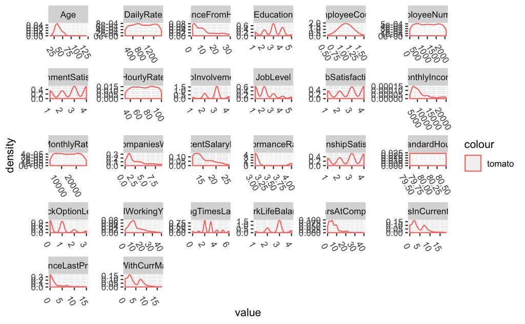

```r
numDF <- rawDF %>%
  keep(is.numeric) %>%                             # Selecteer kolommen met numerieke waarden
  gather()                                         # Converteer naar key:value format
numDF %>% ggplot(aes(value,                        # Bouw grafieken
                     color="tomato")) +            # kleur tomato
    facet_wrap(~ key, scales = "free") +           # in afzonderlijke frames
    geom_density() +                               # als verdeling
    theme(axis.text.x = element_text(angle = -60))  # pas de orientatie van de labels op de x-as aan
```

#### Categorische waarden

```
Ignoring unknown parameters: binwidth, bins, pad
```

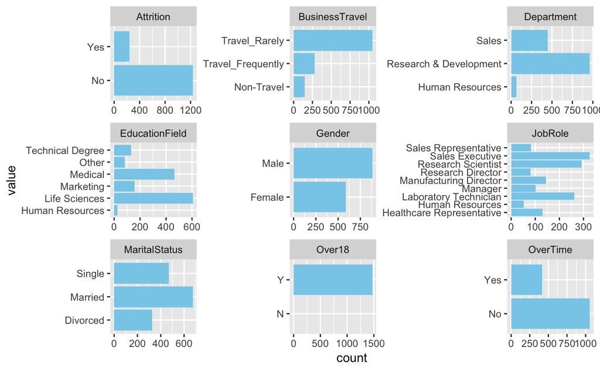

```r
catDF <- rawDF %>%
  keep(is.character) %>%                        # Selecteer kolommen die niet numeriek zijn
  gather()                                      # Converteer naar key:value format
catDF %>% ggplot(aes(value)) +                  # Bouw grafieken
    facet_wrap(~ key, scales = "free") +        # in afzonderlijke frames
    geom_histogram(stat="count",                # als histogrammen
                   fill="skyblue") +            # vulkleur blauw
    coord_flip()                                # switch assen
```